# Assignment 14: Reddit - Text Mining

[figure not shown]

*How to do it?*:

- Open the Rmarkdown file of this assignment (link) in Rstudio.
- Right under each **question**, insert a code chunk (you can use the hotkey `Ctrl + Alt + I` to add a code chunk) and code the solution for the question.
- `Knit` the rmarkdown file (hotkey: `Ctrl + Alt + K`) to export an html.
- Publish the html file to your Githiub Page.

*Submission*: Submit the link on Github of the assignment to Canvas

In this Assignment we will analyze text data scrapped from [Reddit](https://www.reddit.com/), an American social news aggregation, content rating, and discussion website. We will use the package `RedditExtractoR` to help use collect the data.

To learn more about about the package:

https://cran.r-project.org/web/packages/RedditExtractoR/RedditExtractoR.pdf

We use the function `find_thread_urls` to collect the threads in the subreddit `college`.

```r
library(RedditExtractoR)
library(tidytext)
library(ggpubr)
library(tidyverse)
library(knitr)
library(lubridate)

#df <- find_thread_urls(sort_by="new", subreddit = 'college')
```

We can save the data for faster access later and also limit our number of times to inquire the data from Reddit.

```r
#write_csv(df, "reddit_college.csv")
```

```r
library(RedditExtractoR)
library(tidytext)
library(ggpubr)
library(tidyverse)
library(knitr)
library(lubridate)
df = read_csv("reddit_college.csv")
head(df)
```

```
## # A tibble: 6 × 7
##   date_utc    timestamp title                     text  subreddit comments url
##   <date>          <dbl> <chr>                     <chr> <chr>        <dbl> <chr>
## 1 2023-10-31 1698714575 My best friend has anoth… "My … college          2 http…
## 2 2023-10-31 1698714389 If I get a Cencage acces… "I'm… college          0 http…
## 3 2023-10-31 1698713786 Quizlet alternatives?     "I u… college          2 http…
## 4 2023-10-31 1698713343 All the colleges (I can … "Idk… college          7 http…
## 5 2023-10-31 1698711819 What is social life like… "I'm… college          5 http…
## 6 2023-10-31 1698711137 Should I reach out to my… "I'v… college          4 http…
```

## Data Wranggling

The collected dataset has two text columns `title` and `text`. We can create some categorical variables for our analysis.

The `timestamp` variable can give us the time of the day for the threads. We can convert the time to hours (numeric value from 0 to 24).

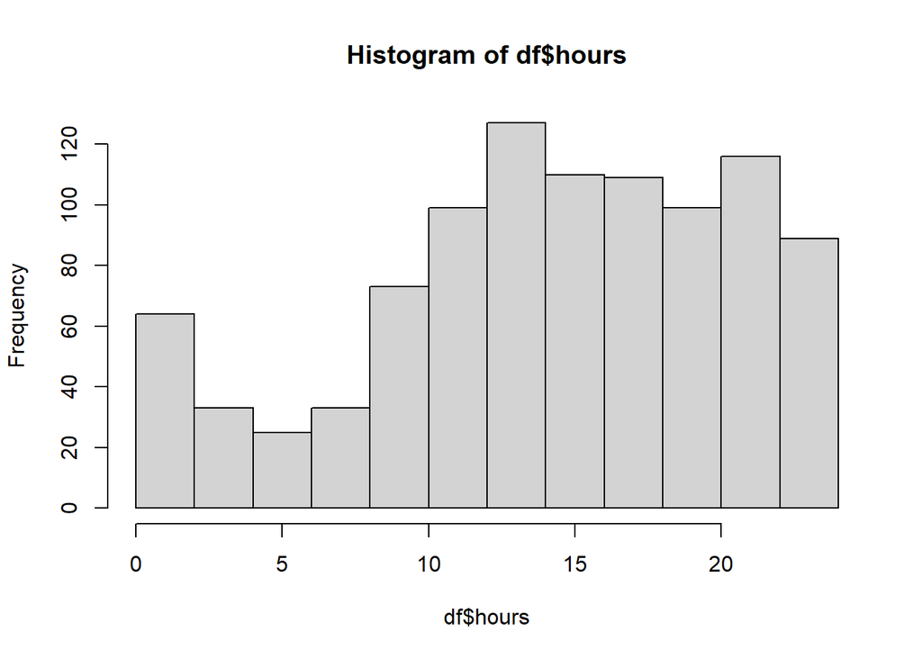

```r
df$date_time = as.POSIXct(df$timestamp)
df = drop_na(df)

# Create a time variable
df$time = format(as.POSIXct(df$date_time), format = "%H:%M:%S")

# change time to hours
df$hours = as.numeric(hms(df$time), "hours")
hist(df$hours)
```

We can create categorical variables for our analysis.

```r
# Create binary variable
df$day_night = case_when(((df$hours >= 7)&(df$hours<=17))~ "day",
                         TRUE ~ "night")

df$threads = case_when(df$comments > 2 ~ "Long",
                         TRUE ~ "Short")
```

## Words Cloud

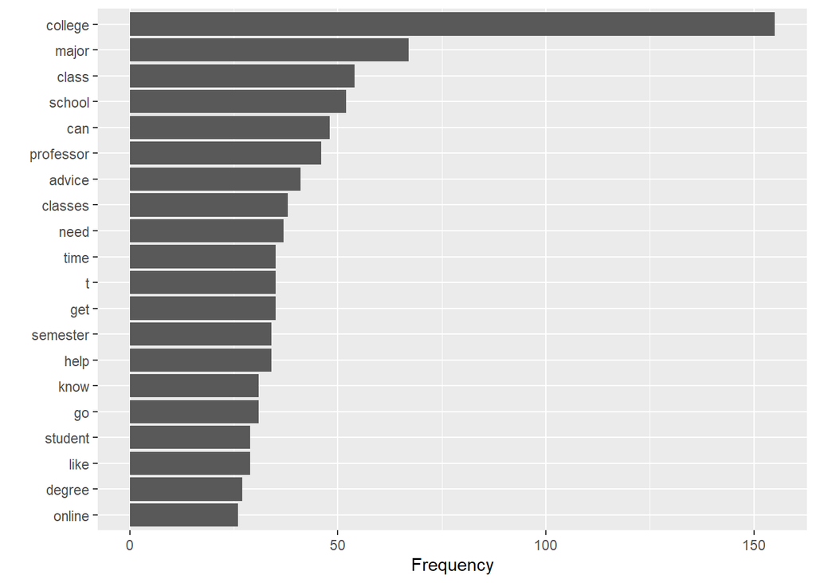

```r
df %>%
  unnest_tokens(input = title, output = word) %>%
  anti_join(get_stopwords()) %>%
  count(word, sort = TRUE) %>%
  head(20) %>%
  ggplot(aes(x = n, y = reorder(word, n))) +
  geom_col() +
  labs(y = '', x = 'Frequency')
```

We notice that there are some words that have only one letter in the frequency. We can filter out these words

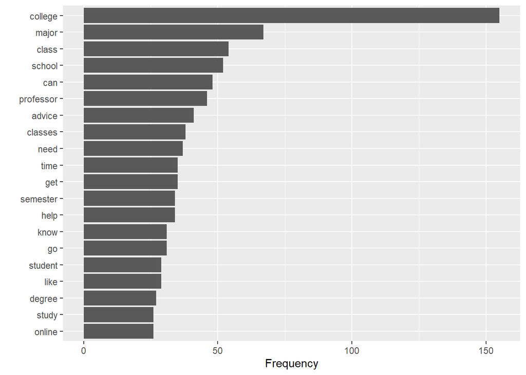

```r
df %>%
  unnest_tokens(input = title, output = word) %>%
  anti_join(get_stopwords()) %>%
  count(word, sort = TRUE) %>%
  filter(nchar(word)>1) %>%
  head(20) %>%
  ggplot(aes(x = n, y = reorder(word, n))) +
  geom_col() +
  labs(y = '', x = 'Frequency')
```

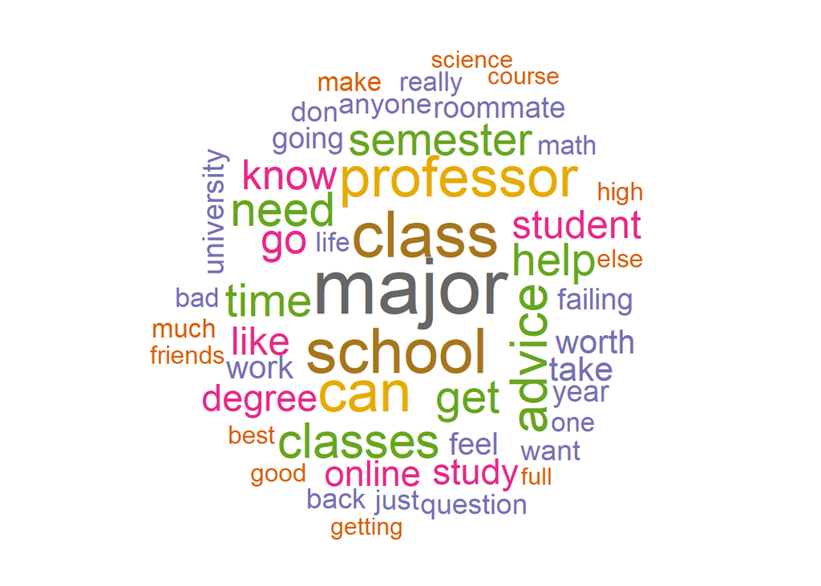

```r
library(wordcloud)
pal <- brewer.pal(8,"Dark2")

df %>%
  unnest_tokens(input = title, output = word) %>%
  anti_join(get_stopwords()) %>%
  count(word, sort = TRUE) %>%
  filter(nchar(word)>1, word!="college") %>%
  with(wordcloud(word, n, random.order = FALSE, max.words = 50, colors=pal))
```

## Sentiment Analysis

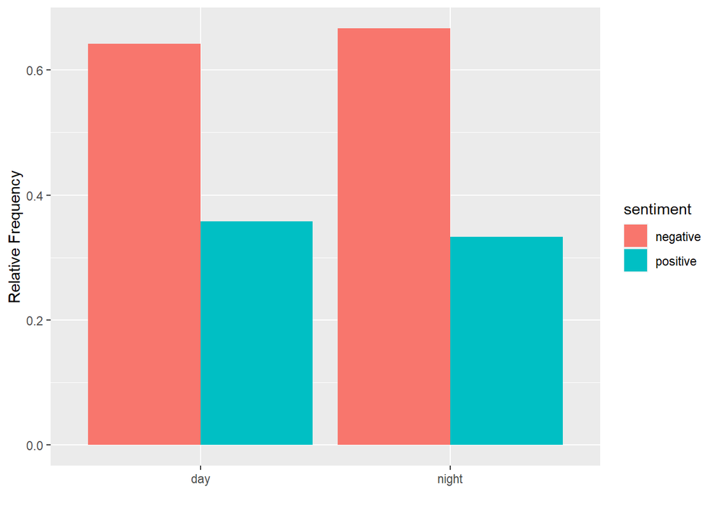

```r
df %>%
    unnest_tokens(input = title, output = word) %>%
    anti_join(get_stopwords()) %>%
    count(day_night, word, sort = TRUE) %>%
    group_by(day_night) %>%
    inner_join(get_sentiments("bing")) %>%
    filter(!is.na(sentiment)) %>%
    count(sentiment, sort = TRUE) %>%
    group_by(day_night) %>%
    mutate(n = n/sum(n)) %>%
    ggplot(aes(day_night, n, fill=sentiment))+geom_col(position = 'dodge')+
    labs(y='Relative Frequency', x ='')
```

## Modeling

Let’s train a model to predict from the title if a thread is long (more than 2 comments) or short (no more than 2 comments).

```r
library(caret)
library(themis)
library(textrecipes)
library(tidyverse)

df = read_csv('reddit_college.csv')

df$threads = case_when(df$comments > 2 ~ "Long",
                         TRUE ~ "Short")

# Select data and set target
df <- df %>%
  mutate(target = threads) %>%
  select(target, title)

# Convert text data to numeric variables
a <- recipe(target~title,
       data = df) %>%
  step_tokenize(title) %>%
  step_tokenfilter(title, max_tokens = 100) %>%
  step_tfidf(title) %>%
  step_normalize(all_numeric_predictors()) %>%
  step_smote(target) %>%
  prep()
df <- juice(a)

# Using Caret for modeling
set.seed(12345)
splitIndex <- createDataPartition(df$target, p = .1,
                                  list = FALSE)
df_train <- df[ splitIndex,]
df_test <- df[-splitIndex,]

forest_ranger <- train(target~., data=df_train,
                        method = "ranger")

pred <- predict(forest_ranger, df_test)

cm <- confusionMatrix(data = pred, reference = df_test$target)
cm$overall[1]
```

```
##  Accuracy
## 0.5640496
```

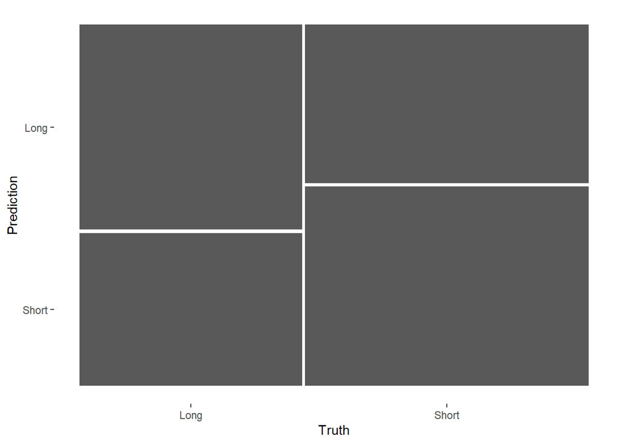

```r
d = data.frame(pred = pred, obs = df_test$target)
library(yardstick)
d %>% conf_mat(pred, obs) %>% autoplot
```

## Question

Collect data from Reddit to do text mining (word clouds, sentiment analysis and modelling) for at least two text variables.

```r
#df <- find_thread_urls(sort_by="new", subreddit = 'NHL')
```

```r
#write_csv(df, "reddit_NHL.csv")
```

```r
df = read_csv("reddit_NHL.csv")
head(df)
```

```
## # A tibble: 6 × 7
##   date_utc    timestamp title                     text  subreddit comments url
##   <date>          <dbl> <chr>                     <chr> <chr>        <dbl> <chr>
## 1 2023-10-15 1697338159 "Cole Caufield dangles K… <NA>  nhl              9 http…
## 2 2023-10-15 1697337655 "Could we be the Dark Ho… <NA>  nhl             21 http…
## 3 2023-10-15 1697336877 "Trouba for Vezina"       <NA>  nhl              7 http…
## 4 2023-10-15 1697336766 "Who\u0019s better"       Who … nhl              9 http…
## 5 2023-10-15 1697336059 "Ryan Reaves vs Marcus F… Sinc… nhl              1 http…
## 6 2023-10-15 1697335834 "Anyone find that the nh… <NA>  nhl              6 http…
```

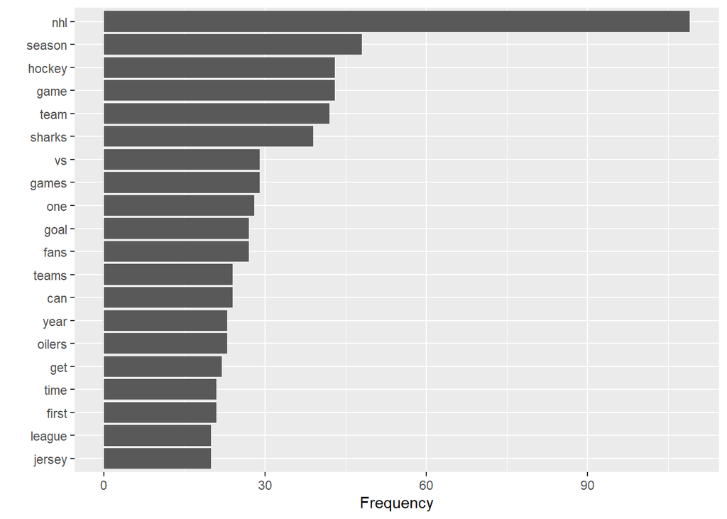

```r
df %>%
  unnest_tokens(input = title, output = word) %>%
  anti_join(get_stopwords()) %>%
  count(word, sort = TRUE) %>%
  filter(nchar(word)>1) %>%
  head(20) %>%
  ggplot(aes(x = n, y = reorder(word, n))) +
  geom_col() +
  labs(y = '', x = 'Frequency')
```

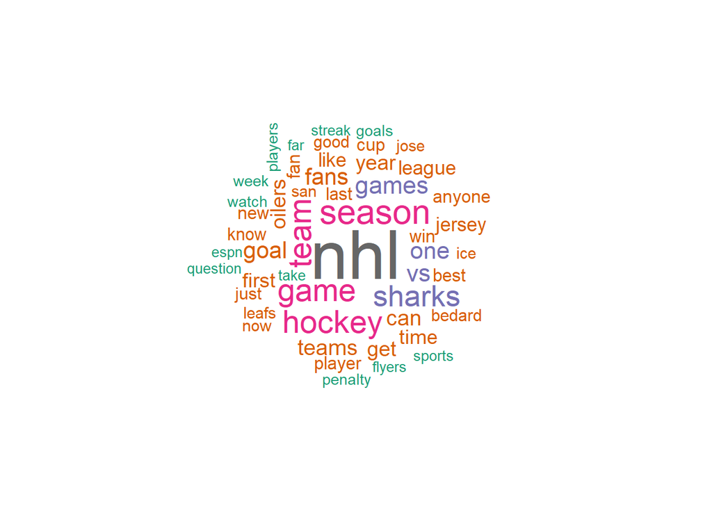

```r
library(wordcloud)
pal <- brewer.pal(8,"Dark2")

df %>%
  unnest_tokens(input = title, output = word) %>%
  anti_join(get_stopwords()) %>%
  count(word, sort = TRUE) %>%
  filter(nchar(word)>1, word!="college") %>%
  with(wordcloud(word, n, random.order = FALSE, max.words = 50, colors=pal))
```

```r
df$numComments = case_when(df$comments > 5 ~ "Long",
                         TRUE ~ "Short")
```

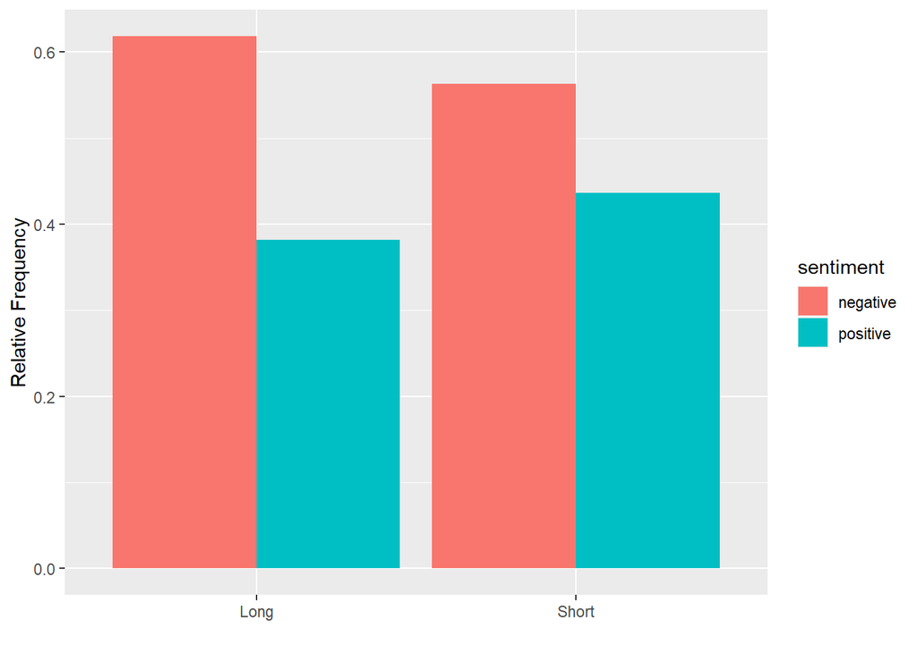

```r
df %>%
    unnest_tokens(input = title, output = word) %>%
    anti_join(get_stopwords()) %>%
    count(numComments, word, sort = TRUE) %>%
    group_by(numComments) %>%
    inner_join(get_sentiments("bing")) %>%
    filter(!is.na(sentiment)) %>%
    count(sentiment, sort = TRUE) %>%
    group_by(numComments) %>%
    mutate(n = n/sum(n)) %>%
    ggplot(aes(numComments, n, fill=sentiment))+geom_col(position = 'dodge')+
    labs(y='Relative Frequency', x ='')
```

```r
library(caret)
library(themis)
library(textrecipes)
library(tidyverse)

df = read_csv('reddit_NHL.csv')

df$threads = case_when(df$comments > 5 ~ "Long",
                         TRUE ~ "Short")

# Select data and set target
df <- df %>%
  mutate(target = threads) %>%
  select(target, title)

# Convert text data to numeric variables
a <- recipe(target~title,
       data = df) %>%
  step_tokenize(title) %>%
  step_tokenfilter(title, max_tokens = 100) %>%
  step_tfidf(title) %>%
  step_normalize(all_numeric_predictors()) %>%
  step_smote(target) %>%
  prep()
df <- juice(a)

# Using Caret for modeling
set.seed(12345)
splitIndex <- createDataPartition(df$target, p = .1,
                                  list = FALSE)
df_train <- df[ splitIndex,]
df_test <- df[-splitIndex,]

forest_ranger <- train(target~., data=df_train,
                        method = "ranger")

pred <- predict(forest_ranger, df_test)

cm <- confusionMatrix(data = pred, reference = df_test$target)
cm$overall[1]
```

```
##  Accuracy
## 0.5743034
```

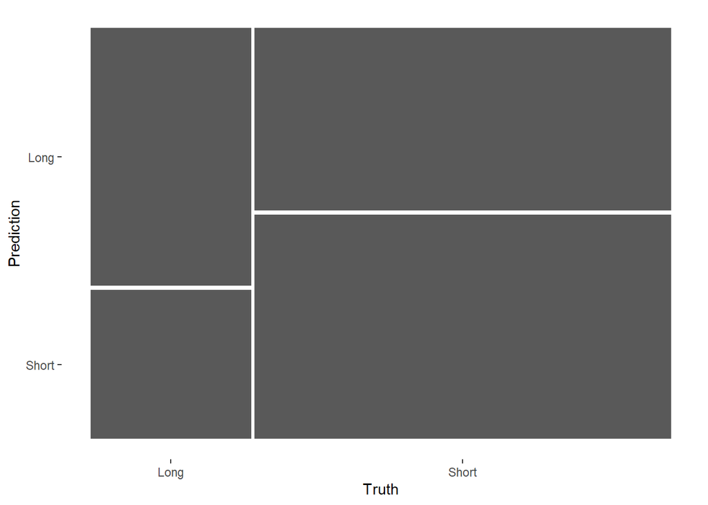

```r
d = data.frame(pred = pred, obs = df_test$target)
library(yardstick)
d %>% conf_mat(pred, obs) %>% autoplot
```

```r
### Reddit subsection 2

#df <- find_thread_urls(sort_by="new", subreddit = 'funny')
```

```r
#write_csv(df, "reddit_funny.csv")
```

```r
df = read_csv("reddit_funny.csv")
head(df)
```

```
## # A tibble: 6 × 7
##   date_utc    timestamp title                     text  subreddit comments url
##   <date>          <dbl> <chr>                     <chr> <chr>        <dbl> <chr>
## 1 2023-11-06 1699302404 "I\u0019ve been spotted"  <NA>  funny            9 http…
## 2 2023-11-06 1699299643 "Balls"                   <NA>  funny          464 http…
## 3 2023-11-06 1699298333 "\u0002\u000f Great star… <NA>  funny            2 http…
## 4 2023-11-06 1699296867 "I live with my landlord" <NA>  funny          125 http…
## 5 2023-11-06 1699294217 "The magical duo of \"An… <NA>  funny            2 http…
## 6 2023-11-06 1699293983 "Something to do with wa… <NA>  funny           35 http…
```

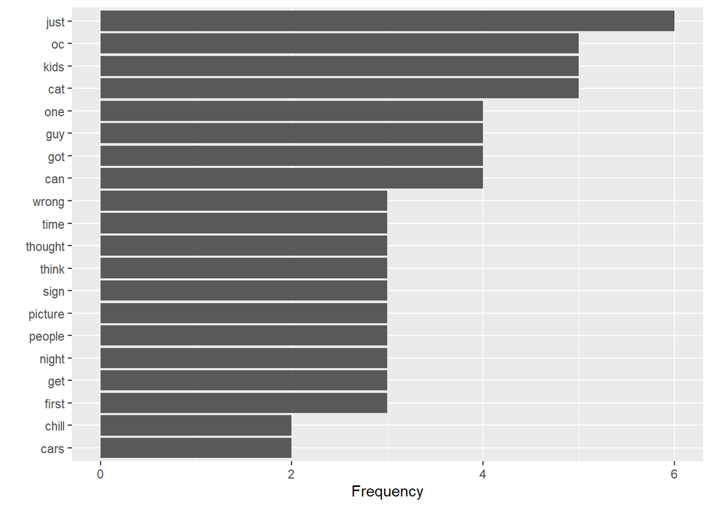

```r
df %>%
  unnest_tokens(input = title, output = word) %>%
  anti_join(get_stopwords()) %>%
  count(word, sort = TRUE) %>%
  filter(nchar(word)>1) %>%
  head(20) %>%
  ggplot(aes(x = n, y = reorder(word, n))) +
  geom_col() +
  labs(y = '', x = 'Frequency')
```

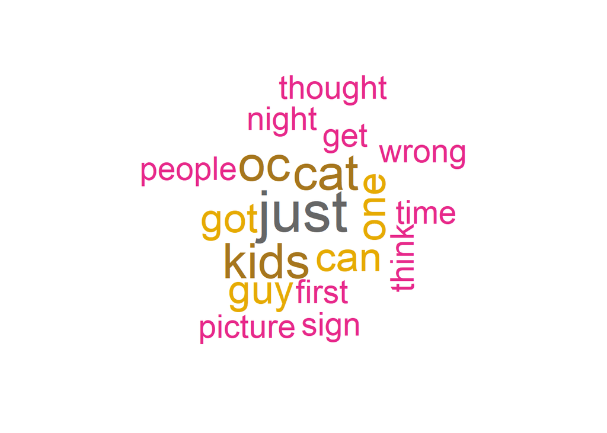

```r
library(wordcloud)
pal <- brewer.pal(8,"Dark2")

df %>%
  unnest_tokens(input = title, output = word) %>%
  anti_join(get_stopwords()) %>%
  count(word, sort = TRUE) %>%
  filter(nchar(word)>1, word!="college") %>%
  with(wordcloud(word, n, random.order = FALSE, max.words = 50, colors=pal))
```

```r
df$numComments = case_when(df$comments > 5 ~ "Long",
                         TRUE ~ "Short")
```

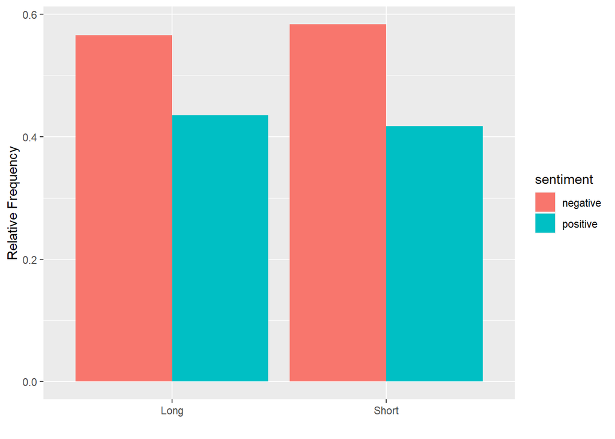

```r
df %>%
    unnest_tokens(input = title, output = word) %>%
    anti_join(get_stopwords()) %>%
    count(numComments, word, sort = TRUE) %>%
    group_by(numComments) %>%
    inner_join(get_sentiments("bing")) %>%
    filter(!is.na(sentiment)) %>%
    count(sentiment, sort = TRUE) %>%
    group_by(numComments) %>%
    mutate(n = n/sum(n)) %>%
    ggplot(aes(numComments, n, fill=sentiment))+geom_col(position = 'dodge')+
    labs(y='Relative Frequency', x ='')
```

```r
library(caret)
library(themis)
library(textrecipes)
library(tidyverse)

df = read_csv('reddit_funny.csv')

df$threads = case_when(df$comments > 2 ~ "Long",
                         TRUE ~ "Short")

# Select data and set target
df <- df %>%
  mutate(target = threads) %>%
  select(target, title)

# Convert text data to numeric variables
a <- recipe(target~title,
       data = df) %>%
  step_tokenize(title) %>%
  step_tokenfilter(title, max_tokens = 100) %>%
  step_tfidf(title) %>%
  step_normalize(all_numeric_predictors()) %>%
  step_smote(target) %>%
  prep()
df <- juice(a)

# Using Caret for modeling
set.seed(12345)
splitIndex <- createDataPartition(df$target, p = .1,
                                  list = FALSE)
df_train <- df[ splitIndex,]
df_test <- df[-splitIndex,]

forest_ranger <- train(target~., data=df_train,
                        method = "ranger")

pred <- predict(forest_ranger, df_test)

cm <- confusionMatrix(data = pred, reference = df_test$target)
cm$overall[1]
```

```
##  Accuracy
## 0.5463918
```

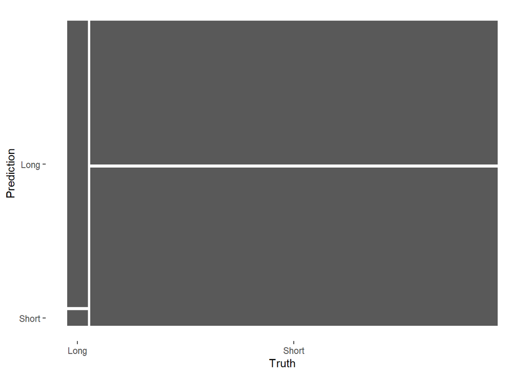

```r
d = data.frame(pred = pred, obs = df_test$target)
library(yardstick)
d %>% conf_mat(pred, obs) %>% autoplot
```